# HomeLens AI: NLP-Based Business Risk Intelligence for Home-Service Providers

## Exploratory Data Analysis — Course Project Milestone 2

**Course:** CIS 509 — Analytics for Unstructured Data  
**Team ID:** HomeLensAI  
**Team Members:** Rithik Roy Thati • Kanha Jodhpurkar • Sankalp Sharma Madgula • Dev Bhattacharyya

> **Submission note:** The assignment requires this executed notebook and its matching HTML export. If Canvas lists a separate numeric Team ID, replace `HomeLensAI` in the heading and file names before submission.

### Project purpose

Home-service companies depend heavily on customer trust, referrals, online reputation, and repeat business. This project examines whether unstructured Yelp review text can reveal recurring **operational and reputational business-risk signals** involving workmanship, reliability, timeliness, pricing, communication, professionalism, warranties, and safety-related complaints.

The analysis intentionally does **not** claim to predict bankruptcy, legal liability, or verified safety violations. It detects review-based signals that may justify management attention.

## Rubric alignment

| Rubric section | Evidence in this notebook |
| --- | --- |
| **1. Team Information** | Team ID and all four members appear above. |
| **2. Project Overview (10%)** | Business problem, stakeholders, analytical question, goals, and scope refinement. |
| **3. Data Sources (10%)** | Yelp source files, extraction logic, selection rules, join key, external links, and reproducibility details. |
| **4. Data Description and Summary Statistics (25%)** | Records, variables, missingness, duplicates, class distributions, document length, sentences, vocabulary, businesses, service groups, and visualizations. |
| **5. Data Quality and Suitability (20%)** | Strengths, sufficiency, weak labels, category overlap, PII, rating leakage, geographic and temporal bias, and preparation challenges. |
| **6. Preliminary Data Exploration (25%)** | NLTK tokenization and n-grams, TextBlob sentiment, spaCy phrase matching, NMF topics, temporal patterns, business-level summaries, and a leakage-aware TF-IDF baseline. |
| **7. Proposed AI Solution (10%)** | Baselines, DistilBERT fine-tuning, aspect validation, business-level aggregation, evaluation plan, and expected output. |
| **8. Generative AI Use** | Disclosure near the end of the notebook. |

The notebook follows the required story: **business problem → data → exploratory findings → proposed AI solution**.

## Google Colab setup

The notebook uses `pandas`, `NumPy`, `matplotlib`, `scikit-learn`, `NLTK`, `spaCy`, `TextBlob`, and `huggingface_hub`. The next cell installs only missing packages when the notebook is running in Google Colab. It does not install anything in an already prepared environment.

```python
import importlib.util
import subprocess
import sys

IN_COLAB = importlib.util.find_spec("google.colab") is not None

required_packages = {
    "pandas": "pandas",
    "numpy": "numpy",
    "matplotlib": "matplotlib",
    "sklearn": "scikit-learn",
    "nltk": "nltk",
    "spacy": "spacy",
    "textblob": "textblob",
    "huggingface_hub": "huggingface_hub",
}

missing = [pip_name for module_name, pip_name in required_packages.items()
           if importlib.util.find_spec(module_name) is None]

if IN_COLAB and missing:
    print("Installing missing Colab packages:", ", ".join(missing))
    subprocess.check_call([sys.executable, "-m", "pip", "install", "-q", *missing])
else:
    print("Package check complete. No installation was required in this execution.")
```

```
Package check complete. No installation was required in this execution.
```

```python
from pathlib import Path
from collections import Counter
import math
import re
import warnings

import numpy as np
import pandas as pd
import matplotlib.pyplot as plt

from IPython.display import display

from nltk.tokenize import RegexpTokenizer
from nltk.util import bigrams
from nltk.stem import SnowballStemmer

import spacy
from spacy.lang.en.stop_words import STOP_WORDS
from spacy.matcher import PhraseMatcher

from textblob import TextBlob

from sklearn.decomposition import NMF
from sklearn.feature_extraction.text import TfidfVectorizer
from sklearn.linear_model import LogisticRegression
from sklearn.metrics import (
    ConfusionMatrixDisplay,
    accuracy_score,
    average_precision_score,
    classification_report,
    confusion_matrix,
    f1_score,
    precision_score,
    recall_score,
    roc_auc_score,
)
from sklearn.model_selection import GroupShuffleSplit

RANDOM_SEED = 509
np.random.seed(RANDOM_SEED)
pd.set_option("display.max_colwidth", 120)
pd.set_option("display.float_format", lambda x: f"{x:,.3f}")
warnings.filterwarnings("ignore", category=FutureWarning)

print("Python:", sys.version.split()[0])
print("pandas:", pd.__version__)
print("spaCy:", spacy.__version__)
```

```
Python: 3.13.15
pandas: 2.2.3
spaCy: 3.8.16
```

```python
from google.colab import drive

drive.mount('/content/gdrive')
```

## Secure Hugging Face authentication for Colab

A Hugging Face token is **not required for the EDA results below**. It will be useful in the next project stage when the team downloads, fine-tunes, or saves transformer models.

In Google Colab:

1. Open the **Secrets** panel using the key icon on the left.
2. Add a secret named `HF_TOKEN`.
3. Paste a personal **read** token from Hugging Face settings.
4. Enable notebook access.

The code below never prints or hard-codes the token. Public models may often be downloaded without authentication, but this secure pattern is preferable for course work and avoids placing credentials inside the submitted notebook.

```python
HF_AUTHENTICATED = False

try:
    if IN_COLAB:
        from google.colab import userdata
        hf_token = userdata.get("HF_TOKEN")
    else:
        hf_token = None

    if hf_token:
        from huggingface_hub import login
        login(token=hf_token, add_to_git_credential=False)
        HF_AUTHENTICATED = True
        print("Hugging Face authentication completed securely through Colab Secrets.")
    else:
        print("HF_TOKEN was not available in this execution. EDA continues without it.")
except Exception as exc:
    print("Hugging Face authentication was skipped safely:", type(exc).__name__)
```

```
Hugging Face authentication completed securely through Colab Secrets.
```

# 1. Team Information

**Team ID:** HomeLensAI  
**Team Members:**

- Rithik Roy Thati
- Kanha Jodhpurkar
- Sankalp Sharma Madgula
- Dev Bhattacharyya

# 2. Project Overview (10%)

## Business problem

Home-service providers—including contractors, plumbers, HVAC companies, roofers, movers, cleaners, property managers, electricians, and repair companies—receive large volumes of customer feedback. Important concerns can be hidden in free-form text and may not be visible from an average star rating alone. A manager needs to know **what went wrong, whether the issue is recurring, whether complaint frequency is changing, and which problem deserves attention first**.

## Main business question

> **Can natural-language processing identify, classify, and explain operational and reputational business-risk signals in Yelp reviews of home-service providers so managers can prioritize corrective action?**

## Stakeholders

Primary users are home-service business owners, operations managers, quality-control teams, customer-experience teams, regional managers, reputation-management teams, and safety or compliance personnel. Customers are secondary beneficiaries because faster identification of recurring problems can improve service quality.

## Analytical goals

1. Describe the text corpus and assess whether it is suitable for NLP.
2. Examine sentiment, vocabulary, phrases, service categories, time trends, and complaint themes.
3. Use NLTK and spaCy for preliminary text processing and risk-aspect extraction.
4. Test whether review language contains enough signal for supervised classification.
5. Design a next-stage AI solution that combines transformer sentiment classification, explainable issue detection, and business-level monitoring.

## Scope refinement

The Milestone 1 concept centered on multimodal real-estate valuation. After confirming that this course project must make meaningful use of unstructured language, the team refined HomeLens AI toward **business-risk intelligence for the home-services industry**. The housing-domain identity remains, while the project now directly applies the course's NLP methods to substantial free-form text.

# 3. Data Sources (10%)

## Original source

The derived project file comes from the **Yelp Open Dataset**, which provides newline-delimited JSON files for businesses and reviews.

- Official dataset page: https://business.yelp.com/data/resources/open-dataset/
- Official documentation: https://www.yelp.com/dataset/documentation/main
- Kaggle mirror used to create the smaller project file: https://www.kaggle.com/datasets/yelp-dataset/yelp-dataset

## Source files and join

- `yelp_academic_dataset_business.json`: business name, location, categories, overall rating, and review count.
- `yelp_academic_dataset_review.json`: review identifiers, star rating, date, engagement counts, and free-form `text`.
- Join key: `business_id`.

## How the project CSV was collected and selected

1. Candidate businesses were selected when the Yelp `categories` field contained a home-related service term.
2. The city-state market with the largest candidate home-service presence in the extraction was selected; the resulting file contains **Tucson, Arizona**.
3. The large review JSON was read in chunks, keeping only reviews whose `business_id` matched a selected business.
4. Reviews were joined to business metadata, blank text and duplicate review IDs were removed, and the result was exported as `HomeLens_Yelp_HomeServices.csv`.
5. This notebook applies a second, documented **core-provider filter** to remove adjacent retail, hotel, apartment-only, and automotive records that entered through broad Yelp categories.

The primary unstructured variable is `text`. Converting the JSON records to CSV does not make the review language structured; the free-form text remains unstructured.

## Load the derived project dataset

```python
DATA_FILENAME_PATTERNS = [
    "HomeLens_Yelp_HomeServices.csv",
    "HomeLens_Yelp_HomeServices(1).csv",
]

candidate_paths = []
for filename in DATA_FILENAME_PATTERNS:
    candidate_paths.extend([
        Path.cwd() / filename,
        Path("/content") / filename,
        Path("/content/drive/MyDrive") / filename,
        Path("/kaggle/working") / filename,
        Path("/mnt/data") / filename,
    ])

DATA_PATH = next((p for p in candidate_paths if p.exists()), None)

if DATA_PATH is None and IN_COLAB:
    from google.colab import files
    print("Upload HomeLens_Yelp_HomeServices.csv")
    uploaded = files.upload()
    uploaded_names = [name for name in uploaded if name.lower().endswith(".csv")]
    if not uploaded_names:
        raise FileNotFoundError("No CSV file was uploaded.")
    DATA_PATH = Path("/content") / uploaded_names[0]

if DATA_PATH is None:
    raise FileNotFoundError(
        "HomeLens_Yelp_HomeServices.csv was not found. "
        "Upload it to Colab or update the candidate paths in this cell."
    )

raw_df = pd.read_csv(DATA_PATH)
raw_df["date"] = pd.to_datetime(raw_df["date"], errors="coerce")

print(f"Loaded: {DATA_PATH.name}")
print(f"Rows: {len(raw_df):,}")
print(f"Columns: {raw_df.shape[1]}")
```

```
Upload HomeLens_Yelp_HomeServices.csv
```

Upload widget is only available when the cell has been executed in the current browser session. Please rerun this cell to enable.

```
Saving HomeLens_Yelp_HomeServices.csv to HomeLens_Yelp_HomeServices.csv
Loaded: HomeLens_Yelp_HomeServices.csv
Rows: 23,685
Columns: 17
```

```python
required_columns = {
    "review_id", "business_id", "user_id", "review_stars", "sentiment_label",
    "date", "text", "useful", "funny", "cool", "name", "city", "state",
    "postal_code", "business_stars", "business_review_count", "categories"
}

missing_required = sorted(required_columns - set(raw_df.columns))
if missing_required:
    raise ValueError(f"The dataset is missing required columns: {missing_required}")

raw_snapshot = pd.DataFrame({
    "Measure": [
        "Candidate reviews", "Candidate businesses", "Unique reviewers",
        "Columns", "Cities", "States", "Earliest review", "Latest review"
    ],
    "Value": [
        f"{len(raw_df):,}",
        f"{raw_df['business_id'].nunique():,}",
        f"{raw_df['user_id'].nunique():,}",
        f"{raw_df.shape[1]}",
        f"{raw_df['city'].nunique():,}",
        f"{raw_df['state'].nunique():,}",
        raw_df['date'].min().date(),
        raw_df['date'].max().date(),
    ]
})
display(raw_snapshot)
```

|  | Measure | Value |
| --- | --- | --- |
| 0 | Candidate reviews | 23,685 |
| 1 | Candidate businesses | 1,403 |
| 2 | Unique reviewers | 16,218 |
| 3 | Columns | 17 |
| 4 | Cities | 1 |
| 5 | States | 1 |
| 6 | Earliest review | 2006-11-26 |
| 7 | Latest review | 2022-01-19 |

## Analytical selection: core home-service providers

Yelp categories are multi-label and broad. The candidate file includes some retailers, hotels, apartment-only listings, utilities, and automotive businesses because they also carried a generic `Home Services` or real-estate category. The following rules retain businesses with at least one clearly operational home-service category, then remove obvious hotel, apartment-only, and primarily automotive records.

This refinement is part of the analysis—not an attempt to make results look better. It makes the business population match the stated decision problem.

|  | Stage | Reviews | Businesses | Share of candidate reviews |
| --- | --- | --- | --- | --- |
| 0 | Candidate extracted Yelp reviews | 23685 | 1403 | 1.000 |
| 1 | Core analytical subset | 17943 | 1054 | 0.758 |
| 2 | Removed as adjacent/non-core | 5742 | 349 | 0.242 |

[figure not shown]

```python
def parse_categories(value):
    return {item.strip() for item in str(value).split(",") if item.strip()}

CORE_CATEGORIES = {
    "Contractors", "General Contractors", "Plumbing",
    "Heating & Air Conditioning/HVAC", "Water Heater Installation/Repair",
    "Electricians", "Roofing", "Landscaping", "Landscape Architects",
    "Gardeners", "Tree Services", "Irrigation", "Lawn Services", "Painters",
    "Flooring", "Tiling", "Carpeting", "Carpet Installation", "Carpet Cleaning",
    "Home Cleaning", "Office Cleaning", "Window Washing", "Pressure Washers",
    "Pest Control", "Pool & Hot Tub Service", "Pool Cleaners", "Swimming Pools",
    "Damage Restoration", "Garage Door Services", "Door Sales/Installation",
    "Windows Installation", "Glass & Mirrors", "Keys & Locksmiths",
    "Security Systems", "Solar Installation", "Home Inspectors", "Handyman",
    "Fences & Gates", "Masonry/Concrete", "Septic Services",
    "Water Purification Services", "Appliances & Repair", "Junk Removal & Hauling",
    "Movers", "Packing Services", "Property Management", "Cabinetry",
    "Countertop Installation", "Kitchen & Bath", "Drywall Installation & Repair",
    "Stucco Services", "Refinishing Services", "Home Organization", "Interior Design",
    "Home Theatre Installation", "Air Duct Cleaning", "Hydro-jetting",
    "Grout Services", "Shades & Blinds", "Shutters",
    "Lighting Fixtures & Equipment", "Furniture Reupholstery", "Metal Fabricators"
}

category_sets = raw_df["categories"].apply(parse_categories)

core_mask = category_sets.apply(lambda values: bool(values & CORE_CATEGORIES))
core_mask &= ~category_sets.apply(lambda values: bool(values & {"Hotels", "Hotels & Travel"}))
core_mask &= ~category_sets.apply(
    lambda values: "Automotive" in values
    and not bool(values & {"Movers", "Junk Removal & Hauling", "Keys & Locksmiths"})
)
core_mask &= ~category_sets.apply(
    lambda values: "Apartments" in values and "Property Management" not in values
)

df = raw_df.loc[core_mask].copy()
df["category_set"] = category_sets.loc[core_mask]

selection_table = pd.DataFrame({
    "Stage": ["Candidate extracted Yelp reviews", "Core analytical subset", "Removed as adjacent/non-core"],
    "Reviews": [len(raw_df), len(df), len(raw_df) - len(df)],
    "Businesses": [raw_df["business_id"].nunique(), df["business_id"].nunique(),
                   raw_df.loc[~core_mask, "business_id"].nunique()],
})
selection_table["Share of candidate reviews"] = selection_table["Reviews"] / len(raw_df)
display(selection_table)

plt.figure(figsize=(8, 4.5))
plt.bar(selection_table["Stage"].iloc[:2], selection_table["Reviews"].iloc[:2])
plt.ylabel("Reviews")
plt.title("Candidate corpus and core home-service analytical subset")
plt.xticks(rotation=10, ha="right")
plt.tight_layout()
plt.show()
```

```python
SERVICE_GROUPS = [
    ("Plumbing & Water", {
        "Plumbing", "Water Heater Installation/Repair", "Hydro-jetting",
        "Septic Services", "Water Purification Services"
    }),
    ("HVAC & Air Quality", {"Heating & Air Conditioning/HVAC", "Air Duct Cleaning"}),
    ("Cleaning & Restoration", {
        "Home Cleaning", "Office Cleaning", "Carpet Cleaning", "Window Washing",
        "Pressure Washers", "Damage Restoration", "Grout Services"
    }),
    ("Outdoor & Landscaping", {
        "Landscaping", "Landscape Architects", "Gardeners", "Tree Services",
        "Irrigation", "Lawn Services", "Pool & Hot Tub Service", "Pool Cleaners",
        "Swimming Pools", "Pest Control"
    }),
    ("Construction & Remodeling", {
        "Contractors", "General Contractors", "Roofing", "Painters", "Flooring",
        "Tiling", "Carpeting", "Carpet Installation", "Kitchen & Bath", "Cabinetry",
        "Countertop Installation", "Drywall Installation & Repair", "Stucco Services",
        "Masonry/Concrete", "Fences & Gates", "Interior Design",
        "Refinishing Services", "Metal Fabricators"
    }),
    ("Electrical, Solar & Security", {
        "Electricians", "Solar Installation", "Security Systems",
        "Lighting Fixtures & Equipment", "Home Theatre Installation"
    }),
    ("Repair & Installation", {
        "Appliances & Repair", "Garage Door Services", "Door Sales/Installation",
        "Windows Installation", "Glass & Mirrors", "Keys & Locksmiths", "Handyman",
        "Shades & Blinds", "Shutters", "Furniture Reupholstery", "Home Organization"
    }),
    ("Moving & Hauling", {"Movers", "Packing Services", "Junk Removal & Hauling"}),
    ("Property Management & Inspection", {"Property Management", "Home Inspectors"}),
]

def assign_service_group(category_set):
    for group_name, group_categories in SERVICE_GROUPS:
        if category_set & group_categories:
            return group_name
    return "Other Core Home Services"

df["service_group"] = df["category_set"].apply(assign_service_group)

# Anonymized provider codes are used in displayed business-level tables.
provider_map = {
    business_id: f"Provider_{number:04d}"
    for number, business_id in enumerate(sorted(df["business_id"].unique()), start=1)
}
df["provider_code"] = df["business_id"].map(provider_map)

print(f"Core reviews retained: {len(df):,}")
print(f"Core businesses retained: {df['business_id'].nunique():,}")
print(f"Unique reviewers retained: {df['user_id'].nunique():,}")
print(f"Location: {df['city'].mode().iat[0]}, {df['state'].mode().iat[0]}")
```

```
Core reviews retained: 17,943
Core businesses retained: 1,054
Unique reviewers retained: 12,384
Location: Tucson, AZ
```

# 4. Data Description and Summary Statistics (25%)

## Original fields

| Field group | Variables | Role |
| --- | --- | --- |
| Review identifiers | `review_id`, `business_id`, `user_id` | Record linkage; IDs are not used as text features. |
| Outcome and time | `review_stars`, `sentiment_label`, `date` | Star-based weak label and temporal analysis. |
| Unstructured text | `text` | Primary NLP input. |
| Review engagement | `useful`, `funny`, `cool` | Structured context. |
| Business context | `name`, `city`, `state`, `postal_code`, `business_stars`, `business_review_count`, `categories` | Filtering, grouping, and business-level analysis. |

The project uses the structured metadata to provide context, but the main analytical contribution comes from the unstructured `text` field.

```python
# Basic corpus and schema summary
schema_table = pd.DataFrame({
    "column": raw_df.columns,
    "dtype": [str(dtype) for dtype in raw_df.dtypes],
    "missing_in_candidate": raw_df.isna().sum().values,
    "unique_values_in_candidate": raw_df.nunique(dropna=True).values,
})
display(schema_table)

summary_table = pd.DataFrame({
    "Measure": [
        "Core documents", "Core businesses", "Unique reviewers", "Original variables",
        "Earliest review", "Latest review", "Location", "Memory used by core subset"
    ],
    "Value": [
        f"{len(df):,}", f"{df['business_id'].nunique():,}", f"{df['user_id'].nunique():,}",
        f"{raw_df.shape[1]}", df['date'].min().date(), df['date'].max().date(),
        f"{df['city'].mode().iat[0]}, {df['state'].mode().iat[0]}",
        f"{df.memory_usage(deep=True).sum() / 1024**2:,.1f} MB"
    ]
})
display(summary_table)
```

|  | column | dtype | missing_in_candidate | unique_values_in_candidate |
| --- | --- | --- | --- | --- |
| 0 | review_id | object | 0 | 23685 |
| 1 | business_id | object | 0 | 1403 |
| 2 | user_id | object | 0 | 16218 |
| 3 | review_stars | int64 | 0 | 5 |
| 4 | sentiment_label | object | 0 | 3 |
| 5 | date | datetime64[ns] | 0 | 23682 |
| 6 | text | object | 0 | 23613 |
| 7 | useful | int64 | 0 | 51 |
| 8 | funny | int64 | 0 | 21 |
| 9 | cool | int64 | 0 | 24 |
| 10 | name | object | 0 | 1339 |
| 11 | city | object | 0 | 1 |
| 12 | state | object | 0 | 1 |
| 13 | postal_code | float64 | 30 | 45 |
| 14 | business_stars | float64 | 0 | 9 |
| 15 | business_review_count | int64 | 0 | 89 |
| 16 | categories | object | 0 | 1016 |

|  | Measure | Value |
| --- | --- | --- |
| 0 | Core documents | 17,943 |
| 1 | Core businesses | 1,054 |
| 2 | Unique reviewers | 12,384 |
| 3 | Original variables | 17 |
| 4 | Earliest review | 2006-11-26 |
| 5 | Latest review | 2022-01-19 |
| 6 | Location | Tucson, AZ |
| 7 | Memory used by core subset | 33.2 MB |

```python
# Missingness and duplicate audit
normalized_text = (
    df["text"].astype(str).str.lower().str.replace(r"\s+", " ", regex=True).str.strip()
)

quality_table = pd.DataFrame({
    "Quality check": [
        "Missing review text", "Blank review text", "Missing review date",
        "Missing postal code", "Duplicate review IDs", "Exact normalized duplicate text"
    ],
    "Count": [
        int(df["text"].isna().sum()),
        int(df["text"].astype(str).str.strip().eq("").sum()),
        int(df["date"].isna().sum()),
        int(df["postal_code"].isna().sum()),
        int(df["review_id"].duplicated().sum()),
        int(normalized_text.duplicated().sum()),
    ]
})
quality_table["Percent of core documents"] = quality_table["Count"] / len(df)
display(quality_table)

print(
    "Decision: all valid review IDs are retained for descriptive EDA. "
    "Exact duplicate text is removed only in the preliminary supervised model to reduce leakage."
)
```

|  | Quality check | Count | Percent of core documents |
| --- | --- | --- | --- |
| 0 | Missing review text | 0 | 0.000 |
| 1 | Blank review text | 0 | 0.000 |
| 2 | Missing review date | 0 | 0.000 |
| 3 | Missing postal code | 30 | 0.002 |
| 4 | Duplicate review IDs | 0 | 0.000 |
| 5 | Exact normalized duplicate text | 54 | 0.003 |

```
Decision: all valid review IDs are retained for descriptive EDA. Exact duplicate text is removed only in the preliminary supervised model to reduce leakage.
```

| review_stars | reviews | percent |
| --- | --- | --- |
| 1 | 5250 | 0.293 |
| 2 | 744 | 0.041 |
| 3 | 457 | 0.025 |
| 4 | 891 | 0.050 |
| 5 | 10601 | 0.591 |

[figure not shown]

| sentiment_label | reviews | percent |
| --- | --- | --- |
| negative | 5994 | 0.334 |
| neutral | 457 | 0.025 |
| positive | 11492 | 0.640 |

```python
# Star and sentiment distributions
star_counts = df["review_stars"].value_counts().sort_index()
star_distribution = pd.DataFrame({
    "reviews": star_counts,
    "percent": star_counts / len(df)
})
display(star_distribution)

plt.figure(figsize=(7, 4.5))
plt.bar(star_counts.index.astype(str), star_counts.values)
plt.xlabel("Yelp review stars")
plt.ylabel("Number of reviews")
plt.title("Core home-service review distribution")
plt.tight_layout()
plt.show()

sentiment_counts = df["sentiment_label"].value_counts().reindex(["negative", "neutral", "positive"])
sentiment_distribution = pd.DataFrame({
    "reviews": sentiment_counts,
    "percent": sentiment_counts / len(df)
})
display(sentiment_distribution)
```

### Interpretation

The corpus is strongly bimodal: five-star and one-star reviews dominate. This is useful for detecting clear positive and negative language, but the neutral class is small. For the preliminary supervised baseline, the notebook therefore uses a business-aligned binary target—**1–2 stars = negative risk signal; 4–5 stars = positive/no immediate risk signal**—and retains three-star reviews for descriptive analysis and later mixed-sentiment error analysis.

```python
# NLTK tokenization and spaCy sentence segmentation
word_tokenizer = RegexpTokenizer(r"[A-Za-z]+(?:'[A-Za-z]+)?")
stemmer = SnowballStemmer("english")

def tokenize_words(text):
    return word_tokenizer.tokenize(str(text).lower())

df["character_count"] = df["text"].astype(str).str.len()
df["word_count"] = df["text"].apply(lambda text: len(tokenize_words(text)))

nlp_sentences = spacy.blank("en")
nlp_sentences.add_pipe("sentencizer")
df["sentence_count"] = [
    sum(1 for _ in document.sents)
    for document in nlp_sentences.pipe(df["text"].astype(str), batch_size=256)
]

document_stats = df[["character_count", "word_count", "sentence_count"]].describe(
    percentiles=[0.25, 0.50, 0.75, 0.90, 0.95, 0.99]
).T

display(document_stats)

all_tokens = []
for review_text in df["text"]:
    all_tokens.extend(tokenize_words(review_text))

content_tokens = [
    token for token in all_tokens
    if len(token) > 2 and token not in STOP_WORDS
]

text_corpus_summary = pd.DataFrame({
    "Measure": [
        "Total word tokens", "Raw vocabulary size", "Content-word vocabulary size",
        "Median words per review", "Mean words per review", "Median sentences per review"
    ],
    "Value": [
        f"{len(all_tokens):,}", f"{len(set(all_tokens)):,}", f"{len(set(content_tokens)):,}",
        f"{df['word_count'].median():,.0f}", f"{df['word_count'].mean():,.1f}",
        f"{df['sentence_count'].median():,.0f}"
    ]
})
display(text_corpus_summary)
```

|  | count | mean | std | min | 25% | 50% | 75% | 90% | 95% | 99% | max |
| --- | --- | --- | --- | --- | --- | --- | --- | --- | --- | --- | --- |
| character_count | 17,943.000 | 635.765 | 591.890 | 2.000 | 274.000 | 458.000 | 777.000 | 1,288.000 | 1,755.800 | 3,031.180 | 5,000.000 |
| word_count | 17,943.000 | 115.350 | 109.028 | 0.000 | 49.000 | 83.000 | 141.000 | 236.000 | 322.000 | 568.000 | 979.000 |
| sentence_count | 17,943.000 | 7.768 | 6.300 | 1.000 | 4.000 | 6.000 | 9.000 | 15.000 | 19.000 | 33.000 | 101.000 |

|  | Measure | Value |
| --- | --- | --- |
| 0 | Total word tokens | 2,069,734 |
| 1 | Raw vocabulary size | 25,113 |
| 2 | Content-word vocabulary size | 24,502 |
| 3 | Median words per review | 83 |
| 4 | Mean words per review | 115.4 |
| 5 | Median sentences per review | 6 |

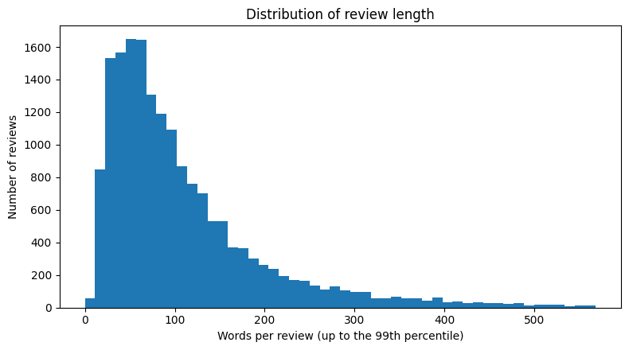

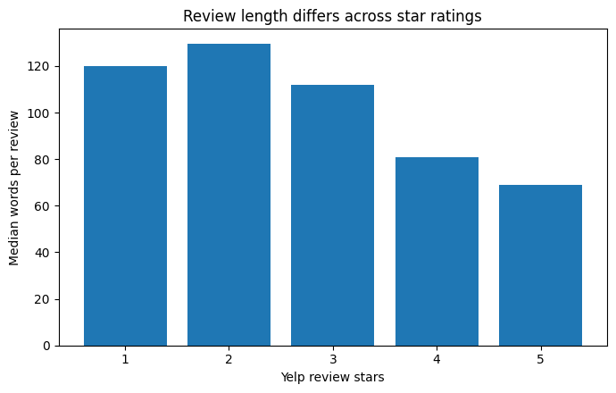

```python
plt.figure(figsize=(8, 4.5))
upper_limit = df["word_count"].quantile(0.99)
plt.hist(df.loc[df["word_count"] <= upper_limit, "word_count"], bins=50)
plt.xlabel("Words per review (up to the 99th percentile)")
plt.ylabel("Number of reviews")
plt.title("Distribution of review length")
plt.tight_layout()
plt.show()

median_words_by_star = df.groupby("review_stars")["word_count"].median()
plt.figure(figsize=(7, 4.5))
plt.bar(median_words_by_star.index.astype(str), median_words_by_star.values)
plt.xlabel("Yelp review stars")
plt.ylabel("Median words per review")
plt.title("Review length differs across star ratings")
plt.tight_layout()
plt.show()
```

## NLTK keyword and n-gram exploration

The following analysis uses NLTK's regular-expression tokenizer and `bigrams`. Stop words are removed with spaCy's English stop-word list so that the displayed terms emphasize business content rather than grammar words. Stemming is available for later modeling, but readable words are retained in the exploratory charts.

```python
def content_word_list(text):
    return [
        token for token in tokenize_words(text)
        if len(token) > 2 and token not in STOP_WORDS
    ]

def top_terms_for_label(label, n=18):
    counter = Counter()
    for review_text in df.loc[df["sentiment_label"] == label, "text"]:
        counter.update(content_word_list(review_text))
    return pd.DataFrame(counter.most_common(n), columns=["term", "count"])

def top_bigrams_for_label(label, n=18):
    counter = Counter()
    for review_text in df.loc[df["sentiment_label"] == label, "text"]:
        tokens = content_word_list(review_text)
        counter.update(" ".join(pair) for pair in bigrams(tokens))
    return pd.DataFrame(counter.most_common(n), columns=["bigram", "count"])

negative_terms = top_terms_for_label("negative")
positive_terms = top_terms_for_label("positive")
negative_bigrams = top_bigrams_for_label("negative")
positive_bigrams = top_bigrams_for_label("positive")

print("Most common negative-review content words")
display(negative_terms)
print("Most common positive-review content words")
display(positive_terms)
```

```
Most common negative-review content words
```

|  | term | count |
| --- | --- | --- |
| 0 | company | 4652 |
| 1 | service | 3549 |
| 2 | called | 3475 |
| 3 | said | 3173 |
| 4 | told | 3112 |
| 5 | time | 3079 |
| 6 | work | 2299 |
| 7 | home | 2067 |
| 8 | house | 2010 |
| 9 | don't | 1855 |
| 10 | day | 1817 |
| 11 | didn't | 1816 |
| 12 | customer | 1577 |
| 13 | came | 1562 |
| 14 | business | 1549 |
| 15 | new | 1541 |
| 16 | like | 1531 |
| 17 | come | 1518 |

```
Most common positive-review content words
```

|  | term | count |
| --- | --- | --- |
| 0 | service | 4863 |
| 1 | great | 4760 |
| 2 | time | 4663 |
| 3 | work | 4464 |
| 4 | job | 3868 |
| 5 | company | 3690 |
| 6 | recommend | 3475 |
| 7 | professional | 3074 |
| 8 | home | 2817 |
| 9 | new | 2729 |
| 10 | came | 2658 |
| 11 | house | 2643 |
| 12 | called | 2384 |
| 13 | highly | 2351 |
| 14 | day | 2211 |
| 15 | good | 1982 |
| 16 | price | 1861 |
| 17 | needed | 1718 |

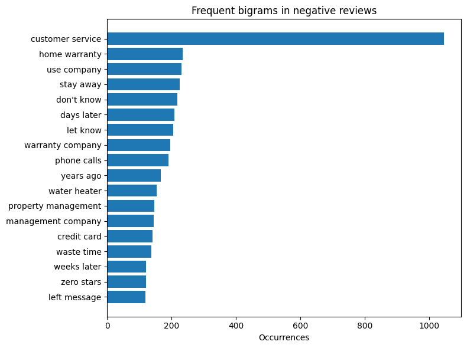

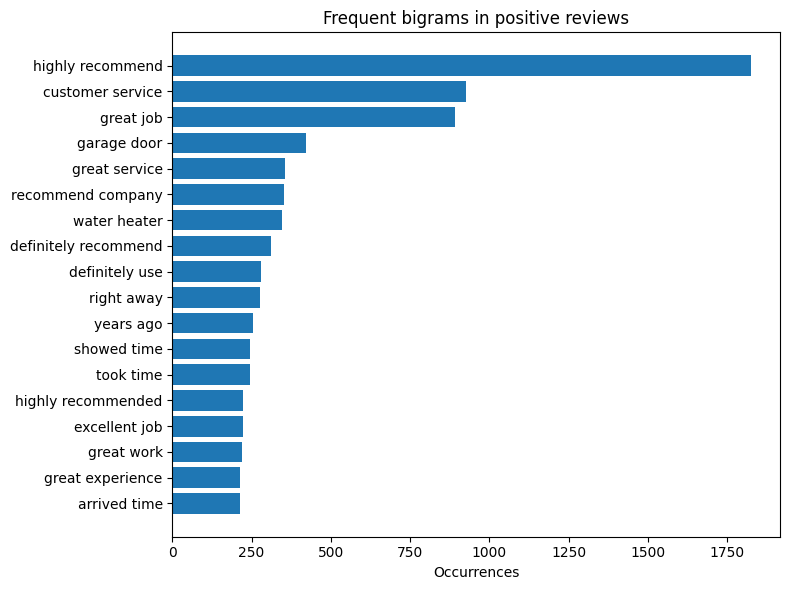

```python
plot_data = negative_bigrams.sort_values("count")
plt.figure(figsize=(8, 6))
plt.barh(plot_data["bigram"], plot_data["count"])
plt.xlabel("Occurrences")
plt.title("Frequent bigrams in negative reviews")
plt.tight_layout()
plt.show()

plot_data = positive_bigrams.sort_values("count")
plt.figure(figsize=(8, 6))
plt.barh(plot_data["bigram"], plot_data["count"])
plt.xlabel("Occurrences")
plt.title("Frequent bigrams in positive reviews")
plt.tight_layout()
plt.show()
```

| service_group | reviews | businesses | average_stars | negative_rate |
| --- | --- | --- | --- | --- |
| Construction & Remodeling | 3724 | 236 | 3.744 | 0.293 |
| Outdoor & Landscaping | 2978 | 205 | 3.811 | 0.287 |
| Plumbing & Water | 2869 | 114 | 3.604 | 0.332 |
| Cleaning & Restoration | 1718 | 115 | 4.049 | 0.224 |
| Repair & Installation | 1564 | 97 | 3.623 | 0.332 |
| Property Management & Inspection | 1404 | 88 | 2.274 | 0.672 |
| HVAC & Air Quality | 1383 | 80 | 3.915 | 0.258 |
| Moving & Hauling | 1280 | 65 | 3.546 | 0.349 |
| Electrical, Solar & Security | 1023 | 54 | 3.204 | 0.433 |

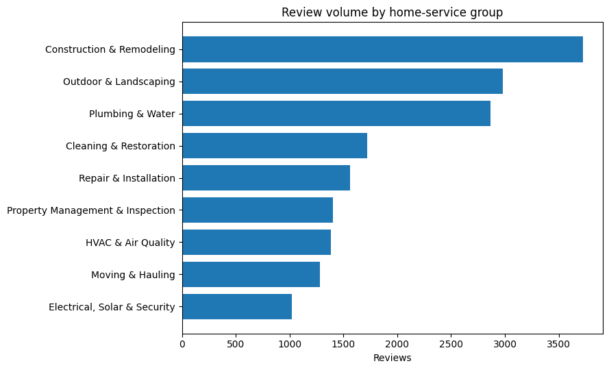

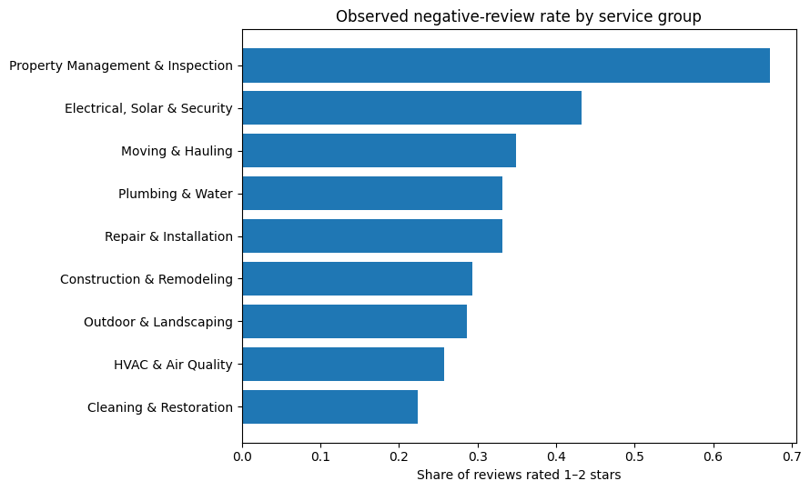

```python
# Service-group size and negative-rate comparison
service_summary = (
    df.groupby("service_group")
      .agg(
          reviews=("review_id", "size"),
          businesses=("business_id", "nunique"),
          average_stars=("review_stars", "mean"),
          negative_rate=("review_stars", lambda values: (values <= 2).mean()),
      )
      .sort_values("reviews", ascending=False)
)
display(service_summary)

plot_data = service_summary.sort_values("reviews")
plt.figure(figsize=(9, 5.5))
plt.barh(plot_data.index, plot_data["reviews"])
plt.xlabel("Reviews")
plt.title("Review volume by home-service group")
plt.tight_layout()
plt.show()

plot_data = service_summary.sort_values("negative_rate")
plt.figure(figsize=(9, 5.5))
plt.barh(plot_data.index, plot_data["negative_rate"])
plt.xlabel("Share of reviews rated 1–2 stars")
plt.title("Observed negative-review rate by service group")
plt.tight_layout()
plt.show()
```

### Interpretation

Observed complaint rates differ considerably by service group. These are **descriptive associations**, not causal quality judgments. Property-management reviews, for example, may reflect ongoing tenant-landlord conflicts and stronger self-selection than one-time repair services. The final system should therefore compare a provider with similar businesses and should not use one universal threshold without context.

# 5. Data Quality and Suitability (20%)

## Why the data are suitable

- The analytical subset contains a large collection of long, natural-language documents and thousands of negative examples.
- Reviews include outcomes, explanations, emotions, service events, timing, prices, staff behavior, and follow-up experiences that are not captured by an average rating alone.
- Business metadata allows industry grouping, business-level aggregation, and time-based monitoring.
- The corpus supports multiple course methods: NLTK tokenization and n-grams, TextBlob sentiment, spaCy rule matching, TF-IDF, topic modeling, and later transformer fine-tuning.

## Important limitations and potential biases

1. **Geographic scope:** the file contains Tucson, Arizona, so results may not generalize to other markets.
2. **Historical period:** reviews extend through January 2022 and do not represent current 2026 conditions.
3. **Self-selection:** people who post reviews may differ from customers who do not, and extreme experiences may be overrepresented.
4. **Weak labels:** star ratings are practical sentiment labels, but text can be mixed, sarcastic, or inconsistent with the rating.
5. **Uneven business coverage:** some providers have many reviews and others have few; business-level conclusions require a minimum review threshold and uncertainty adjustment.
6. **Category overlap:** Yelp categories are multi-label, requiring transparent inclusion and exclusion rules.
7. **Complaint verification:** allegations in reviews are not verified facts. A safety phrase is a **safety-related complaint signal**, not proof of a violation.
8. **PII and credentials:** review text can contain phone numbers, email addresses, or URLs. These should be masked before modeling and should not be reproduced in reports.
9. **Target leakage:** some reviewers write explicit phrases such as “one star” or “five stars.” These phrases must be masked in a star-derived sentiment model.
10. **Temporal incompleteness:** January 2022 is only a partial year and should not be compared directly with full years.

## Preparation and analysis challenges

- Negation, sarcasm, misspellings, long narratives, and domain-specific terms complicate sentiment analysis.
- A random row split could leak provider-specific language into the test set; the preliminary model therefore holds out entire businesses.
- Exact duplicate text is small but is removed from supervised modeling.
- The neutral class is limited, so binary risk classification is the most stable first supervised task.

## Privacy and target-leakage audit

The audit below identifies text patterns that need masking before supervised modeling. Money references are useful to pricing-risk analysis, so the exact value is replaced with a generic token rather than deleting the entire phrase.

|  | pattern | reviews | percent |
| --- | --- | --- | --- |
| 4 | Currency amount | 2248 | 0.125 |
| 0 | Explicit star-rating phrase | 1013 | 0.056 |
| 1 | Phone number | 49 | 0.003 |
| 3 | URL | 43 | 0.002 |
| 2 | Email address | 14 | 0.001 |

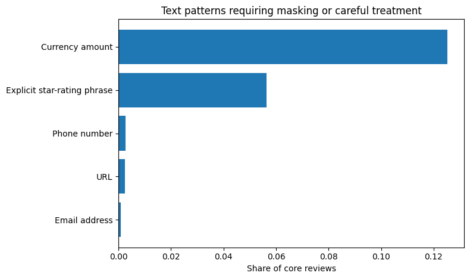

```python
AUDIT_PATTERNS = {
    "Explicit star-rating phrase": r"\b(?:zero|one|two|three|four|five|first|second|third|fourth|fifth|[0-5](?:st|nd|rd|th)?)[- ]?star(?:s)?\b",
    "Phone number": r"\b(?:\+?1[-.\s]?)?\(?\d{3}\)?[-.\s]\d{3}[-.\s]\d{4}\b",
    "Email address": r"\b[A-Za-z0-9._%+-]+@[A-Za-z0-9.-]+\.[A-Za-z]{2,}\b",
    "URL": r"(?:https?://|www\.)\S+",
    "Currency amount": r"\$\s?\d[\d,]*(?:\.\d{2})?",
}

audit_rows = []
for pattern_name, pattern in AUDIT_PATTERNS.items():
    matched = df["text"].str.contains(pattern, case=False, regex=True, na=False)
    audit_rows.append({
        "pattern": pattern_name,
        "reviews": int(matched.sum()),
        "percent": float(matched.mean()),
    })

audit_table = pd.DataFrame(audit_rows).sort_values("reviews", ascending=False)
display(audit_table)

plt.figure(figsize=(8, 4.8))
plot_data = audit_table.sort_values("percent")
plt.barh(plot_data["pattern"], plot_data["percent"])
plt.xlabel("Share of core reviews")
plt.title("Text patterns requiring masking or careful treatment")
plt.tight_layout()
plt.show()
```

```python
MASKING_RULES = [
    (r"(?:https?://|www\.)\S+", " URLTOKEN "),
    (r"\b[A-Za-z0-9._%+-]+@[A-Za-z0-9.-]+\.[A-Za-z]{2,}\b", " EMAILTOKEN "),
    (r"\b(?:\+?1[-.\s]?)?\(?\d{3}\)?[-.\s]\d{3}[-.\s]\d{4}\b", " PHONETOKEN "),
    (r"\$\s?\d[\d,]*(?:\.\d{2})?", " MONEYTOKEN "),
    (r"\b(?:zero|one|two|three|four|five|first|second|third|fourth|fifth|[0-5](?:st|nd|rd|th)?)[- ]?star(?:s)?\b", " RATINGTOKEN "),
]

def mask_sensitive_and_leakage(text):
    cleaned = str(text)
    for pattern, replacement in MASKING_RULES:
        cleaned = re.sub(pattern, replacement, cleaned, flags=re.IGNORECASE)
    return re.sub(r"\s+", " ", cleaned).strip()

df["model_text"] = df["text"].apply(mask_sensitive_and_leakage)

# Demonstrate the transformation without exposing full reviews or provider names.
masking_demo = pd.DataFrame({
    "original_excerpt": df["text"].head(3).str.slice(0, 180),
    "masked_excerpt": df["model_text"].head(3).str.slice(0, 180),
})
display(masking_demo)
```

|  | original_excerpt | masked_excerpt |
| --- | --- | --- |
| 0 | They have a lot of safes here. Small and large. I even saw a big safe deposit box with dozens of drawers for sale. | They have a lot of safes here. Small and large. I even saw a big safe deposit box with dozens of drawers for sale. |
| 3 | Responsive, timely, and kind.\nEdited to add the fifth star for being Competent!\nDelightful. | Responsive, timely, and kind. Edited to add the RATINGTOKEN for being Competent! Delightful. |
| 4 | I guess I should trust by gut instincts when I see web design that is that embarrasingly BAD. But, you know, 24-hou... | I guess I should trust by gut instincts when I see web design that is that embarrasingly BAD. But, you know, 24-hour... |

# 6. Preliminary Data Exploration (25%)

## 6.1 Lexicon-based sentiment benchmark with TextBlob

TextBlob provides a fast polarity benchmark ranging from negative to positive. It is not the final model; it helps determine whether simple dictionary-style sentiment captures the language in this domain and where contextual models may add value.

| review_stars | count | mean | median | std |
| --- | --- | --- | --- | --- |
| 1 | 5250 | -0.020 | 0.000 | 0.197 |
| 2 | 744 | 0.075 | 0.074 | 0.162 |
| 3 | 457 | 0.153 | 0.138 | 0.157 |
| 4 | 891 | 0.239 | 0.217 | 0.162 |
| 5 | 10601 | 0.298 | 0.283 | 0.171 |

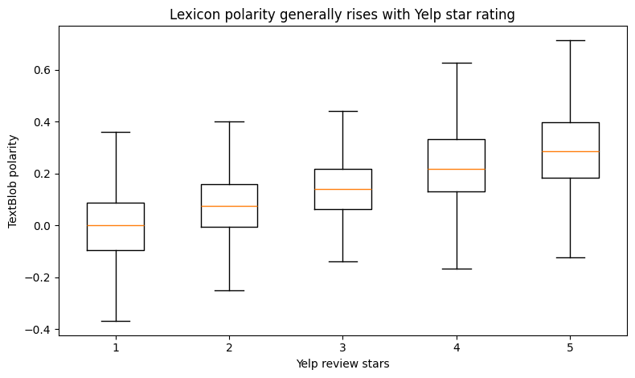

```python
df["textblob_polarity"] = df["text"].apply(lambda text: TextBlob(str(text)).sentiment.polarity)

polarity_by_star = (
    df.groupby("review_stars")["textblob_polarity"]
      .agg(["count", "mean", "median", "std"])
)
display(polarity_by_star)

# Sample for a readable boxplot while preserving the original star distribution.
plot_sample = pd.concat(
    [
        group.sample(min(len(group), 1500), random_state=RANDOM_SEED)
        for _, group in df.groupby("review_stars")
    ],
    ignore_index=True,
)

boxplot_values = [
    plot_sample.loc[plot_sample["review_stars"] == stars, "textblob_polarity"]
    for stars in sorted(plot_sample["review_stars"].unique())
]

plt.figure(figsize=(8, 4.8))
plt.boxplot(boxplot_values, tick_labels=[str(star) for star in sorted(plot_sample["review_stars"].unique())],
            showfliers=False)
plt.xlabel("Yelp review stars")
plt.ylabel("TextBlob polarity")
plt.title("Lexicon polarity generally rises with Yelp star rating")
plt.tight_layout()
plt.show()
```

```python
# Binary business-risk benchmark: 1–2 stars = negative; 4–5 stars = positive.
textblob_eval = df[df["review_stars"] != 3].copy()
textblob_eval["actual_negative"] = (textblob_eval["review_stars"] <= 2).astype(int)
textblob_eval["predicted_negative"] = (textblob_eval["textblob_polarity"] < 0).astype(int)

textblob_report = pd.DataFrame(
    classification_report(
        textblob_eval["actual_negative"],
        textblob_eval["predicted_negative"],
        target_names=["positive", "negative"],
        output_dict=True,
        zero_division=0,
    )
).T

display(textblob_report)
print("Confusion matrix [rows = actual, columns = predicted]:")
display(pd.DataFrame(
    confusion_matrix(textblob_eval["actual_negative"], textblob_eval["predicted_negative"]),
    index=["Actual positive", "Actual negative"],
    columns=["Predicted positive", "Predicted negative"],
))
```

|  | precision | recall | f1-score | support |
| --- | --- | --- | --- | --- |
| positive | 0.772 | 0.978 | 0.863 | 11,492.000 |
| negative | 0.915 | 0.447 | 0.601 | 5,994.000 |
| accuracy | 0.796 | 0.796 | 0.796 | 0.796 |
| macro avg | 0.844 | 0.713 | 0.732 | 17,486.000 |
| weighted avg | 0.821 | 0.796 | 0.773 | 17,486.000 |

```
Confusion matrix [rows = actual, columns = predicted]:
```

|  | Predicted positive | Predicted negative |
| --- | --- | --- |
| Actual positive | 11243 | 249 |
| Actual negative | 3312 | 2682 |

### Interpretation

The lexicon score moves in the expected direction as stars increase, but it misses many negative reviews. Home-service complaints frequently contain long narratives, negation, mixed praise and criticism, or factual descriptions whose risk comes from context rather than strongly negative adjectives. This supports comparing a trained TF-IDF classifier and a contextual transformer with the lexicon baseline.

## 6.2 spaCy rule-based extraction of business-risk aspects

A blank English spaCy pipeline is sufficient for reliable tokenization, sentence boundaries, and `PhraseMatcher` patterns. The phrase dictionary is intentionally transparent and should be refined through manual review. Each match indicates a **review signal**, not a verified event.

```python
RISK_PHRASES = {
    "Workmanship": [
        "poor quality", "bad job", "terrible job", "sloppy work", "unfinished work",
        "not finished", "installed incorrectly", "incorrect installation", "repair failed",
        "did not fix", "didn't fix", "still leaking", "stopped working", "made it worse",
        "broke again", "poor workmanship", "damaged the", "damaged my"
    ],
    "Reliability / No-show": [
        "no show", "never showed", "did not show", "didn't show", "never came",
        "did not come", "didn't come", "missed appointment", "cancelled appointment",
        "canceled appointment", "failed to arrive"
    ],
    "Timeliness": [
        "arrived late", "showed up late", "hours late", "days late", "project delayed",
        "missed deadline", "took weeks", "took months", "long wait", "still waiting",
        "slow service"
    ],
    "Pricing / Billing": [
        "overcharged", "charged more", "hidden fee", "hidden fees", "unexpected charge",
        "extra charge", "price changed", "estimate changed", "bait and switch",
        "too expensive", "way too expensive", "rip off", "ripped off"
    ],
    "Communication": [
        "never called back", "did not call back", "didn't call back", "no response",
        "never responded", "did not respond", "didn't respond", "stopped responding",
        "poor communication", "no communication", "would not return my call",
        "wouldn't return my call"
    ],
    "Professionalism / Trust": [
        "very rude", "rude staff", "unprofessional", "dishonest", "lied to me",
        "misleading", "scam", "fraud", "disrespectful", "aggressive behavior"
    ],
    "Safety / Property Damage": [
        "unsafe", "dangerous", "fire hazard", "electrical hazard", "gas leak",
        "water damage", "flooded my", "damaged my property", "mold problem", "safety issue"
    ],
    "Warranty / Follow-up": [
        "warranty not honored", "would not honor", "refused to fix", "would not fix",
        "wouldn't fix", "follow up repair", "follow-up repair", "return visit",
        "under warranty", "warranty claim"
    ],
}

nlp_matcher = spacy.blank("en")
nlp_matcher.add_pipe("sentencizer")
phrase_matcher = PhraseMatcher(nlp_matcher.vocab, attr="LOWER")

for aspect, phrases in RISK_PHRASES.items():
    phrase_matcher.add(aspect, [nlp_matcher.make_doc(phrase) for phrase in phrases])

aspect_columns = []
for aspect in RISK_PHRASES:
    column = "aspect_" + re.sub(r"\W+", "_", aspect.lower()).strip("_")
    aspect_columns.append(column)
    df[column] = False

for row_index, document in zip(df.index, nlp_matcher.pipe(df["text"].astype(str), batch_size=256)):
    matched_aspects = {nlp_matcher.vocab.strings[match_id] for match_id, _, _ in phrase_matcher(document)}
    for aspect in matched_aspects:
        column = "aspect_" + re.sub(r"\W+", "_", aspect.lower()).strip("_")
        df.at[row_index, column] = True

aspect_rows = []
for aspect in RISK_PHRASES:
    column = "aspect_" + re.sub(r"\W+", "_", aspect.lower()).strip("_")
    mentions = int(df[column].sum())
    negative_mentions = int((df[column] & (df["review_stars"] <= 2)).sum())
    aspect_rows.append({
        "aspect": aspect,
        "reviews_with_signal": mentions,
        "negative_reviews_with_signal": negative_mentions,
        "negative_rate_when_mentioned": negative_mentions / mentions if mentions else np.nan,
    })

aspect_summary = pd.DataFrame(aspect_rows).sort_values("reviews_with_signal", ascending=False)
display(aspect_summary)
```

|  | aspect | reviews_with_signal | negative_reviews_with_signal | negative_rate_when_mentioned |
| --- | --- | --- | --- | --- |
| 5 | Professionalism / Trust | 806 | 765 | 0.949 |
| 1 | Reliability / No-show | 378 | 324 | 0.857 |
| 0 | Workmanship | 281 | 181 | 0.644 |
| 3 | Pricing / Billing | 276 | 181 | 0.656 |
| 4 | Communication | 245 | 214 | 0.873 |
| 2 | Timeliness | 158 | 127 | 0.804 |
| 6 | Safety / Property Damage | 136 | 85 | 0.625 |
| 7 | Warranty / Follow-up | 100 | 68 | 0.680 |

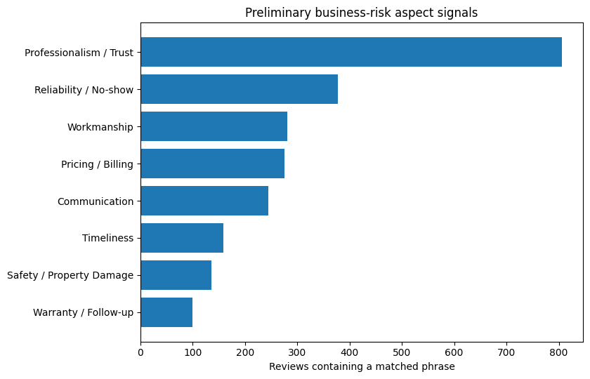

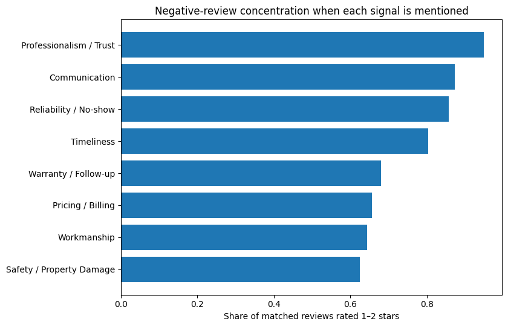

```python
plot_data = aspect_summary.sort_values("reviews_with_signal")
plt.figure(figsize=(8.5, 5.5))
plt.barh(plot_data["aspect"], plot_data["reviews_with_signal"])
plt.xlabel("Reviews containing a matched phrase")
plt.title("Preliminary business-risk aspect signals")
plt.tight_layout()
plt.show()

plot_data = aspect_summary.sort_values("negative_rate_when_mentioned")
plt.figure(figsize=(8.5, 5.5))
plt.barh(plot_data["aspect"], plot_data["negative_rate_when_mentioned"])
plt.xlabel("Share of matched reviews rated 1–2 stars")
plt.title("Negative-review concentration when each signal is mentioned")
plt.tight_layout()
plt.show()
```

```python
# Display anonymized and masked evidence excerpts for selected aspects.
def first_masked_example(aspect_name):
    column = "aspect_" + re.sub(r"\W+", "_", aspect_name.lower()).strip("_")
    candidates = df.loc[df[column] & (df["review_stars"] <= 2), ["provider_code", "review_stars", "model_text"]]
    if candidates.empty:
        return None
    row = candidates.sample(1, random_state=RANDOM_SEED).iloc[0]
    return {
        "aspect": aspect_name,
        "provider": row["provider_code"],
        "stars": int(row["review_stars"]),
        "masked_excerpt": row["model_text"][:320] + ("…" if len(row["model_text"]) > 320 else ""),
    }

example_rows = [first_masked_example(aspect) for aspect in RISK_PHRASES]
example_rows = [row for row in example_rows if row is not None]
display(pd.DataFrame(example_rows))
```

|  | aspect | provider | stars | masked_excerpt |
| --- | --- | --- | --- | --- |
| 0 | Workmanship | Provider_0137 | 1 | I would strongly suggest that no landlord or renter works with this company. We are currently renting a home that th... |
| 1 | Reliability / No-show | Provider_0601 | 1 | This deplorable excuse for a service company was contracted through our home warranty to fix a built in microwave. T... |
| 2 | Timeliness | Provider_0382 | 1 | Terrible company. Comcast is the only company offering cable in our area and so clearly they don't think they need t... |
| 3 | Pricing / Billing | Provider_0979 | 1 | STAY AWAY FROM THIS PLACE! IT'S A BAIT AND SWITCH. On Saturday we were given a special for a 12-month lease (even ha... |
| 4 | Communication | Provider_0342 | 1 | I am extremely upset with this company, I would not recommend them to anyone that is looking at using a moving compa... |
| 5 | Professionalism / Trust | Provider_0379 | 1 | Another review primarily for geek squad but it says a lot about the company and their customer service. They have ki... |
| 6 | Safety / Property Damage | Provider_0307 | 1 | This company installed a saltwater system for us and said they knew how to maintain it. We had the same guy for mont... |
| 7 | Warranty / Follow-up | Provider_0997 | 1 | Years ago I had Alaskan do their Annual inspection. There worker I won't even call him a technician said the voltage... |

### Interpretation

Professionalism/trust, communication, reliability/no-show, and timeliness phrases are especially concentrated in low-star reviews. Workmanship, pricing, warranties, and safety-related language also appear, but simple phrase rules cannot capture every paraphrase or determine whether an allegation is true. The next stage should validate these rules against a human-coded sample before they are used operationally.

## 6.3 Topic discovery within negative reviews

Non-negative Matrix Factorization (NMF) is applied only to 1–2 star reviews. TF-IDF reduces common language and allows recurring complaint themes to emerge without assigning labels in advance.

```python
negative_reviews = df[df["review_stars"] <= 2].copy()

topic_stop_words = sorted(
    {word for word in STOP_WORDS if word.isalpha()}
    | {
        "business", "company", "service", "services", "called", "call", "said",
        "told", "would", "could", "one", "get", "got", "time", "work", "use",
        "used", "also", "back", "even", "really"
    }
)

topic_vectorizer = TfidfVectorizer(
    stop_words=topic_stop_words,
    min_df=8,
    max_df=0.75,
    max_features=5000,
    ngram_range=(1, 2),
    sublinear_tf=True,
)
negative_tfidf = topic_vectorizer.fit_transform(negative_reviews["model_text"])

nmf_model = NMF(
    n_components=6,
    init="nndsvda",
    random_state=RANDOM_SEED,
    max_iter=400,
)
topic_weights = nmf_model.fit_transform(negative_tfidf)
topic_terms = np.array(topic_vectorizer.get_feature_names_out())

TOPIC_LABELS = {
    1: "Work, cleaning, and moving outcomes",
    2: "Property management and lease disputes",
    3: "Scheduling, appointments, and follow-up",
    4: "Warranty, equipment, and repair failure",
    5: "Customer service and professionalism",
    6: "Pricing, estimates, and billing",
}

topic_rows = []
for topic_number, component in enumerate(nmf_model.components_, start=1):
    top_words = topic_terms[component.argsort()[-12:][::-1]]
    topic_rows.append({
        "topic": topic_number,
        "interpretive_label": TOPIC_LABELS[topic_number],
        "top_terms": ", ".join(top_words),
    })

topic_table = pd.DataFrame(topic_rows)
display(topic_table)

negative_reviews["dominant_topic"] = topic_weights.argmax(axis=1) + 1
topic_counts = negative_reviews["dominant_topic"].value_counts().sort_index()
topic_count_table = pd.DataFrame({
    "topic": topic_counts.index,
    "negative_reviews": topic_counts.values,
    "interpretive_label": [TOPIC_LABELS[number] for number in topic_counts.index],
})
display(topic_count_table)
```

|  | topic | interpretive_label | top_terms |
| --- | --- | --- | --- |
| 0 | 1 | Work, cleaning, and moving outcomes | job, house, clean, cleaning, left, didn, moving, furniture, cleaned, movers, carpet, truck |
| 1 | 2 | Property management and lease disputes | property, rent, management, lease, deposit, property management, rental, worst, moved, month, place, tenants |
| 2 | 3 | Scheduling, appointments, and follow-up | appointment, day, phone, scheduled, showed, days, week, later, schedule, come, message, morning |
| 3 | 4 | Warranty, equipment, and repair failure | warranty, unit, home, fix, new, ac, repair, problem, water, came, installed, system |
| 4 | 5 | Customer service and professionalism | customer, don, store, rude, like, help, people, know, bad, want, customers, buy |
| 5 | 6 | Pricing, estimates, and billing | moneytoken, charged, charge, charged moneytoken, cost, estimate, price, fee, moneytoken moneytoken, bill, pay, quote |

|  | topic | negative_reviews | interpretive_label |
| --- | --- | --- | --- |
| 0 | 1 | 751 | Work, cleaning, and moving outcomes |
| 1 | 2 | 925 | Property management and lease disputes |
| 2 | 3 | 1149 | Scheduling, appointments, and follow-up |
| 3 | 4 | 884 | Warranty, equipment, and repair failure |
| 4 | 5 | 1561 | Customer service and professionalism |
| 5 | 6 | 724 | Pricing, estimates, and billing |

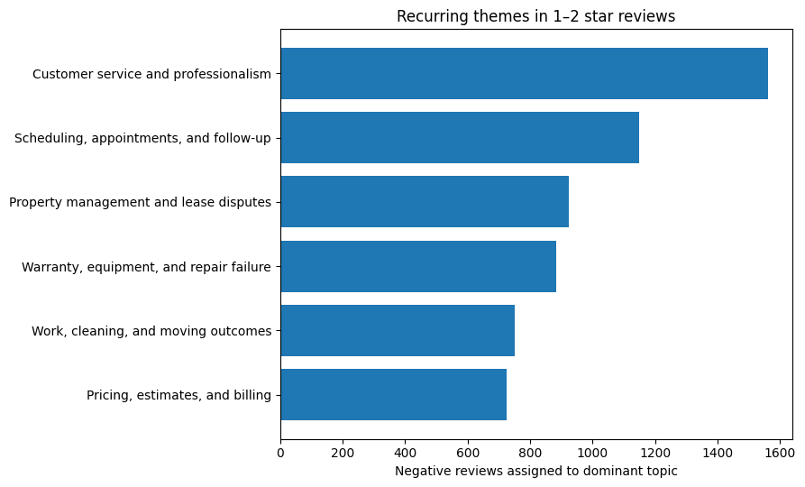

```python
plot_data = topic_count_table.sort_values("negative_reviews")
plt.figure(figsize=(9, 5.5))
plt.barh(plot_data["interpretive_label"], plot_data["negative_reviews"])
plt.xlabel("Negative reviews assigned to dominant topic")
plt.title("Recurring themes in 1–2 star reviews")
plt.tight_layout()
plt.show()
```

### Interpretation

The unsupervised topics independently recover complaint areas that are useful to management: repair and warranty failures, appointment problems, unanswered communication, customer-service conduct, property-management disputes, and moving or cleaning outcomes. This agreement between n-grams, rule-based aspects, and NMF strengthens the business case for a multi-part NLP solution.

## 6.4 Time patterns

The final year in the file contains only part of January 2022, so the trend chart ends at 2021. Years with very few reviews are shown in the table but should not receive equal interpretive weight.

| review_year | reviews | average_stars | negative_rate |
| --- | --- | --- | --- |
| 2006 | 1 | 3.000 | 0.000 |
| 2007 | 5 | 3.400 | 0.400 |
| 2008 | 17 | 3.412 | 0.412 |
| 2009 | 20 | 3.700 | 0.250 |
| 2010 | 60 | 3.967 | 0.183 |
| 2011 | 194 | 3.397 | 0.335 |
| 2012 | 349 | 3.335 | 0.387 |
| 2013 | 533 | 3.353 | 0.390 |
| 2014 | 956 | 3.377 | 0.382 |
| 2015 | 1319 | 3.516 | 0.357 |
| 2016 | 1845 | 3.663 | 0.316 |
| 2017 | 2130 | 3.696 | 0.308 |
| 2018 | 2549 | 3.650 | 0.327 |
| 2019 | 2727 | 3.651 | 0.326 |
| 2020 | 2522 | 3.785 | 0.292 |
| 2021 | 2594 | 3.462 | 0.375 |
| 2022 | 122 | 3.246 | 0.443 |

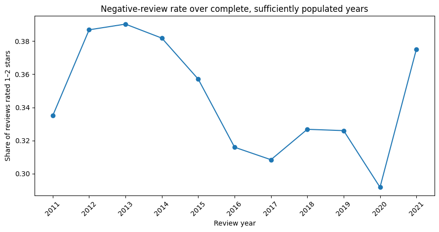

```python
df["review_year"] = df["date"].dt.year

yearly_summary = (
    df.groupby("review_year")
      .agg(
          reviews=("review_id", "size"),
          average_stars=("review_stars", "mean"),
          negative_rate=("review_stars", lambda values: (values <= 2).mean()),
      )
)
display(yearly_summary)

complete_years = yearly_summary.loc[(yearly_summary.index <= 2021) & (yearly_summary["reviews"] >= 100)]

plt.figure(figsize=(9, 4.8))
plt.plot(complete_years.index, complete_years["negative_rate"], marker="o")
plt.xlabel("Review year")
plt.ylabel("Share of reviews rated 1–2 stars")
plt.title("Negative-review rate over complete, sufficiently populated years")
plt.xticks(complete_years.index, rotation=45)
plt.tight_layout()
plt.show()
```

### Interpretation

The negative-review rate is not constant over time. Changes may reflect real operating conditions, platform participation, category composition, economic conditions, or reviewer behavior. The final dashboard should therefore show trends with review volume and should avoid treating a single yearly movement as causal evidence.

## 6.5 Business-level signal sufficiency

Individual-review classification can use every valid review. Business-level summaries require more evidence. The table below uses a minimum of 20 reviews and a Wilson lower confidence bound so a provider with a small number of negative reviews does not automatically rank above a provider with substantial evidence. Provider names are anonymized because this assignment evaluates the method, not individual companies.

```python
def wilson_lower_bound(negative_count, total_count, z=1.96):
    if total_count == 0:
        return np.nan
    proportion = negative_count / total_count
    denominator = 1 + (z ** 2) / total_count
    center = proportion + (z ** 2) / (2 * total_count)
    margin = z * math.sqrt(
        (proportion * (1 - proportion) / total_count) + (z ** 2) / (4 * total_count ** 2)
    )
    return (center - margin) / denominator

business_summary = (
    df.groupby("business_id")
      .agg(
          provider_code=("provider_code", "first"),
          service_group=("service_group", "first"),
          reviews=("review_id", "size"),
          negative_count=("review_stars", lambda values: int((values <= 2).sum())),
          average_stars=("review_stars", "mean"),
          latest_review=("date", "max"),
      )
      .reset_index(drop=True)
)
business_summary["negative_rate"] = business_summary["negative_count"] / business_summary["reviews"]
business_summary["negative_rate_wilson_lower"] = business_summary.apply(
    lambda row: wilson_lower_bound(row["negative_count"], row["reviews"]), axis=1
)

threshold_table = pd.DataFrame({
    "Minimum reviews": [10, 20, 30],
    "Eligible businesses": [
        int((business_summary["reviews"] >= threshold).sum()) for threshold in [10, 20, 30]
    ]
})
display(threshold_table)

# Determine the most frequently matched aspect for each business.
aspect_counts_by_business = df.groupby("business_id")[aspect_columns].sum()
max_aspect_column = aspect_counts_by_business.idxmax(axis=1)
max_aspect_count = aspect_counts_by_business.max(axis=1)
column_to_label = {
    "aspect_" + re.sub(r"\W+", "_", aspect.lower()).strip("_"): aspect
    for aspect in RISK_PHRASES
}
top_aspect = max_aspect_column.map(column_to_label)
top_aspect[max_aspect_count == 0] = "No dictionary match"

business_summary["top_matched_aspect"] = business_summary["provider_code"].map(
    dict(zip(
        df.drop_duplicates("business_id")["provider_code"],
        df.drop_duplicates("business_id")["business_id"].map(top_aspect)
    ))
)

eligible_businesses = business_summary[business_summary["reviews"] >= 20].copy()
review_signal_table = (
    eligible_businesses
    .sort_values(["negative_rate_wilson_lower", "reviews"], ascending=[False, False])
    [[
        "provider_code", "service_group", "reviews", "average_stars", "negative_rate",
        "negative_rate_wilson_lower", "top_matched_aspect", "latest_review"
    ]]
    .head(12)
)

display(review_signal_table)
```

|  | Minimum reviews | Eligible businesses |
| --- | --- | --- |
| 0 | 10 | 566 |
| 1 | 20 | 254 |
| 2 | 30 | 147 |

|  | provider_code | service_group | reviews | average_stars | negative_rate | negative_rate_wilson_lower | top_matched_aspect | latest_review |
| --- | --- | --- | --- | --- | --- | --- | --- | --- |
| 234 | Provider_0235 | Cleaning & Restoration | 25 | 1.040 | 1.000 | 0.867 | Professionalism / Trust | 2016-12-18 17:16:09 |
| 439 | Provider_0440 | Construction & Remodeling | 106 | 1.425 | 0.896 | 0.824 | Reliability / No-show | 2022-01-19 16:30:50 |
| 696 | Provider_0697 | Electrical, Solar & Security | 45 | 1.356 | 0.911 | 0.793 | Professionalism / Trust | 2021-12-07 20:37:08 |
| 495 | Provider_0496 | Property Management & Inspection | 59 | 1.458 | 0.881 | 0.775 | Professionalism / Trust | 2021-12-14 22:16:14 |
| 341 | Provider_0342 | Moving & Hauling | 108 | 1.574 | 0.843 | 0.762 | Professionalism / Trust | 2021-12-08 20:59:03 |
| 441 | Provider_0442 | Electrical, Solar & Security | 25 | 1.360 | 0.920 | 0.750 | Workmanship | 2021-07-27 23:16:17 |
| 544 | Provider_0545 | Repair & Installation | 95 | 1.674 | 0.832 | 0.744 | Reliability / No-show | 2022-01-14 00:03:28 |
| 906 | Provider_0907 | Property Management & Inspection | 55 | 1.473 | 0.855 | 0.738 | Professionalism / Trust | 2021-12-01 23:03:08 |
| 610 | Provider_0611 | Property Management & Inspection | 33 | 1.485 | 0.879 | 0.727 | Professionalism / Trust | 2020-07-01 10:02:53 |
| 425 | Provider_0426 | Plumbing & Water | 52 | 1.538 | 0.846 | 0.725 | Reliability / No-show | 2021-10-02 00:50:39 |
| 301 | Provider_0302 | Property Management & Inspection | 50 | 1.540 | 0.840 | 0.715 | Professionalism / Trust | 2020-09-08 09:30:40 |
| 179 | Provider_0180 | Property Management & Inspection | 36 | 1.444 | 0.861 | 0.713 | Communication | 2021-12-08 16:28:54 |

### Interpretation

A substantial number of businesses have enough reviews for provider-level monitoring, but the score must remain a **decision-support signal**. The final system should display evidence, uncertainty, recency, and peer context rather than publishing an unsupported list of “risky” companies.

## 6.6 Preliminary supervised text-classification feasibility test

This is a lightweight baseline—not the final tuned model. It tests whether text can distinguish clear negative-risk reviews from positive reviews.

Methodological safeguards:

- Three-star reviews are excluded from this binary feasibility test.
- URLs, emails, phone numbers, exact money values, and explicit star phrases are masked.
- Exact normalized duplicate text is removed.
- Entire businesses, rather than random rows, are held out with `GroupShuffleSplit`, preventing provider-specific language from appearing in both training and testing.
- Class weights reduce the effect of the remaining label imbalance.

```python
model_df = df[df["review_stars"] != 3].copy()
model_df["normalized_model_text"] = (
    model_df["model_text"].str.lower().str.replace(r"\s+", " ", regex=True).str.strip()
)
model_df = model_df.drop_duplicates(subset="normalized_model_text").copy()
model_df["target_negative"] = (model_df["review_stars"] <= 2).astype(int)

group_split = GroupShuffleSplit(n_splits=1, test_size=0.20, random_state=RANDOM_SEED)
train_index, test_index = next(
    group_split.split(model_df, model_df["target_negative"], groups=model_df["business_id"])
)
train_df = model_df.iloc[train_index].copy()
test_df = model_df.iloc[test_index].copy()

vectorizer = TfidfVectorizer(
    lowercase=True,
    strip_accents="unicode",
    stop_words="english",
    ngram_range=(1, 2),
    min_df=3,
    max_df=0.95,
    max_features=35000,
    sublinear_tf=True,
)

X_train = vectorizer.fit_transform(train_df["model_text"])
X_test = vectorizer.transform(test_df["model_text"])

baseline_model = LogisticRegression(
    class_weight="balanced",
    max_iter=1000,
    solver="liblinear",
    random_state=RANDOM_SEED,
)
baseline_model.fit(X_train, train_df["target_negative"])

negative_probability = baseline_model.predict_proba(X_test)[:, 1]
baseline_prediction = (negative_probability >= 0.50).astype(int)

print(f"Training reviews: {len(train_df):,}")
print(f"Test reviews: {len(test_df):,}")
print(f"Training businesses: {train_df['business_id'].nunique():,}")
print(f"Held-out businesses: {test_df['business_id'].nunique():,}")
print("Business overlap:", len(set(train_df["business_id"]) & set(test_df["business_id"])))
```

```
Training reviews: 13,999
Test reviews: 3,434
Training businesses: 843
Held-out businesses: 211
Business overlap: 0
```

|  | Metric | Value |
| --- | --- | --- |
| 0 | Accuracy | 0.945 |
| 1 | Macro F1 | 0.942 |
| 2 | Negative precision | 0.904 |
| 3 | Negative recall | 0.956 |
| 4 | Negative F1 | 0.929 |
| 5 | Average Precision | 0.984 |
| 6 | ROC-AUC | 0.990 |

|  | precision | recall | f1-score | support |
| --- | --- | --- | --- | --- |
| positive | 0.972 | 0.937 | 0.955 | 2,127.000 |
| negative | 0.904 | 0.956 | 0.929 | 1,307.000 |
| accuracy | 0.945 | 0.945 | 0.945 | 0.945 |
| macro avg | 0.938 | 0.947 | 0.942 | 3,434.000 |
| weighted avg | 0.946 | 0.945 | 0.945 | 3,434.000 |

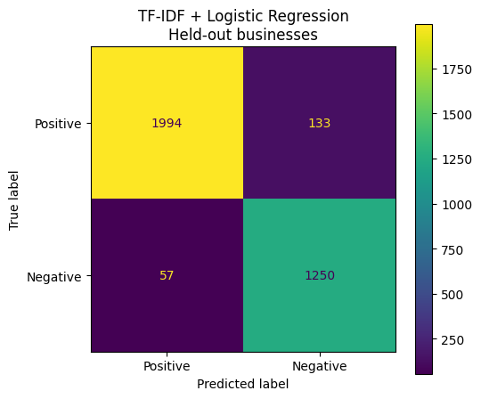

```python
baseline_metrics = pd.DataFrame({
    "Metric": [
        "Accuracy", "Macro F1", "Negative precision", "Negative recall",
        "Negative F1", "Average Precision", "ROC-AUC"
    ],
    "Value": [
        accuracy_score(test_df["target_negative"], baseline_prediction),
        f1_score(test_df["target_negative"], baseline_prediction, average="macro"),
        precision_score(test_df["target_negative"], baseline_prediction, pos_label=1),
        recall_score(test_df["target_negative"], baseline_prediction, pos_label=1),
        f1_score(test_df["target_negative"], baseline_prediction, pos_label=1),
        average_precision_score(test_df["target_negative"], negative_probability),
        roc_auc_score(test_df["target_negative"], negative_probability),
    ]
})
display(baseline_metrics)

baseline_report = pd.DataFrame(
    classification_report(
        test_df["target_negative"],
        baseline_prediction,
        target_names=["positive", "negative"],
        output_dict=True,
        zero_division=0,
    )
).T
display(baseline_report)

figure, axis = plt.subplots(figsize=(5.5, 4.8))
ConfusionMatrixDisplay.from_predictions(
    test_df["target_negative"],
    baseline_prediction,
    display_labels=["Positive", "Negative"],
    values_format="d",
    ax=axis,
)
axis.set_title("TF-IDF + Logistic Regression\nHeld-out businesses")
figure.tight_layout()
plt.show()
```

```python
# Error analysis uses masked excerpts and no provider names.
error_table = test_df[["provider_code", "review_stars", "model_text"]].copy()
error_table["actual_negative"] = test_df["target_negative"].values
error_table["predicted_negative"] = baseline_prediction
error_table["negative_probability"] = negative_probability
error_table["error_type"] = np.select(
    [
        (error_table["actual_negative"] == 1) & (error_table["predicted_negative"] == 0),
        (error_table["actual_negative"] == 0) & (error_table["predicted_negative"] == 1),
    ],
    ["False negative", "False positive"],
    default="Correct",
)

error_groups = []
for error_type, group in error_table[error_table["error_type"] != "Correct"].groupby("error_type"):
    sampled_group = group.sample(min(3, len(group)), random_state=RANDOM_SEED).copy()
    error_groups.append(sampled_group)

sampled_errors = pd.concat(error_groups, ignore_index=True) if error_groups else pd.DataFrame(
    columns=error_table.columns
)
sampled_errors["masked_excerpt"] = sampled_errors["model_text"].str.slice(0, 320)

display(sampled_errors[[
    "error_type", "provider_code", "review_stars", "negative_probability", "masked_excerpt"
]])
```

|  | error_type | provider_code | review_stars | negative_probability | masked_excerpt |
| --- | --- | --- | --- | --- | --- |
| 0 | False negative | Provider_0718 | 1 | 0.464 | Bunch of criminals. It looks like they're posting positive reviews of themselves. They ran over my dog! |
| 1 | False negative | Provider_0182 | 2 | 0.213 | The store is large and has many options. It's a bit more on the antique side of style and a bit expensive. I'm not s... |
| 2 | False negative | Provider_0535 | 1 | 0.452 | I was looking for a company in Tucson to help me unload my Uhaul. I confirmed the date and time with Anthony a coupl... |
| 3 | False positive | Provider_0305 | 4 | 0.600 | We had a sales rep come out on. A tues.very nice told him What we needed he showed me samples. We picked one out . H... |
| 4 | False positive | Provider_0040 | 5 | 0.798 | Ed is the most honest and reliable A/C guy i have ever used. On the hottest day of the year our a/c went out. Ed cam... |
| 5 | False positive | Provider_0802 | 5 | 0.806 | I called my friend who had a hot water heater put in by another company a month before for a recommendation. She sai... |

### Interpretation

The business-held-out TF-IDF model substantially outperforms the lexicon benchmark, showing that review language contains strong predictive signal beyond individual keywords. The high score should not be treated as the final business solution: star ratings are directly expressed through customer language, and sentiment alone does not explain **which operational issue** management should fix. Error analysis also shows why mixed narratives and indirect complaints remain difficult.

# Key exploratory findings

1. **Sufficient NLP corpus:** the core subset contains **17,943 reviews from 1,054 home-service businesses**, with about **2.07 million word tokens** and a median of roughly **83 words per review**.
2. **Useful negative evidence:** the subset contains **5,994 reviews rated 1–2 stars**, providing enough examples for risk-oriented text classification and theme discovery.
3. **Operational language is visible:** negative n-grams emphasize unanswered calls, delays, warranty problems, and warnings to other customers; positive language emphasizes quality, timeliness, professionalism, and fair pricing.
4. **Service context matters:** observed negative rates vary sharply by service group, so provider monitoring should use peer context rather than a single global threshold.
5. **Simple sentiment is insufficient:** TextBlob follows star direction but misses many negative narratives, supporting a trained contextual model.
6. **Multiple methods converge:** spaCy phrase matching and NMF both reveal communication, scheduling, professionalism, repair, warranty, and property-management themes.
7. **Business-level monitoring is feasible:** **254 providers have at least 20 reviews** in the analytical subset, enough for a cautious dashboard with uncertainty adjustment.
8. **Model feasibility is strong:** a leakage-masked TF-IDF baseline evaluated on entirely held-out businesses achieves strong macro-F1 and negative-class recall, demonstrating that the text supports the proposed next stage.
9. **Responsible treatment is required:** the data are historical, Tucson-specific, self-selected, and based on unverified customer accounts. Outputs must be labeled as review-based signals rather than verified violations or financial-failure predictions.

# 7. Proposed AI Solution (10%)

## Proposed system

The next stage will create an explainable **HomeLens Business Risk Intelligence** pipeline:

```
Yelp review text
      ↓
PII, money, URL, and rating-phrase masking
      ↓
Sentiment / negative-risk classification
      ↓
Business-risk aspect detection
      ↓
Evidence-sentence extraction
      ↓
Provider-level aggregation with time and uncertainty
      ↓
Management dashboard and recommended investigation priority
```

## Model comparison

1. **Lexicon baseline:** TextBlob and optional NLTK VADER.
2. **Classical baseline:** TF-IDF unigrams/bigrams with class-weighted Logistic Regression or Linear SVM.
3. **Transformer model:** fine-tune `distilbert-base-uncased` using Hugging Face for negative-risk classification. DistilBERT is selected because it is smaller and faster than full BERT while preserving contextual language information.
4. **Aspect layer:** begin with the transparent spaCy phrase matcher, manually annotate a stratified sample of negative reviews, and evaluate or fine-tune a multi-label aspect classifier if time permits.
5. **Business layer:** aggregate review probabilities, repeated aspects, recent trend, review volume, and uncertainty. Require at least 20 reviews for published provider summaries.

## Training and validation design

- Mask direct rating phrases and PII before modeling.
- Keep natural punctuation and word order for DistilBERT; do not stem transformer input.
- Compare a **business-held-out split** with a **chronological sensitivity test**.
- Tune thresholds on validation data rather than automatically using 0.50.
- Preserve an untouched final test set.

## Evaluation

### Sentiment / negative-risk model

- Macro F1
- Negative-class precision, recall, and F1
- Average Precision / PR-AUC
- Confusion matrix
- Performance by service group and review length

### Aspect extraction

- Human annotation of a review sample
- Precision, recall, and F1 for each aspect
- False-positive and missed-phrase analysis

### Business dashboard

- Minimum review threshold and Wilson or Bayesian smoothing
- Recent versus prior negative-rate trend
- Evidence sentences supporting each alert
- No claim of bankruptcy, legal liability, fraud, or verified unsafe conduct

## Expected business output

```
Provider: Provider_XXXX
Review-based risk tier: Elevated
Recent negative-review rate: increasing
Primary issue: Communication
Secondary issue: Workmanship
Evidence: masked customer sentence
Recommended management action: inspect callback procedures and repeat-repair cases
```

The proposed solution helps managers prioritize operational investigation, quality improvement, customer recovery, and reputation management. It does not replace human review.

## Hugging Face next-stage Colab scaffold

The EDA does not train a transformer. In the next milestone, install the model packages and use the secure login cell near the top of this notebook:

```
# Next-stage only
!pip -q install transformers datasets accelerate evaluate

from transformers import AutoTokenizer, AutoModelForSequenceClassification

MODEL_NAME = "distilbert-base-uncased"
tokenizer = AutoTokenizer.from_pretrained(MODEL_NAME)
model = AutoModelForSequenceClassification.from_pretrained(
    MODEL_NAME,
    num_labels=2,
)
```

The team should never paste an `hf_...` token directly into a code or markdown cell. Use the Colab secret named `HF_TOKEN`.

# 8. Generative AI Use

**Generative AI disclosure:** The team used ChatGPT as a learning and productivity aid to help organize the notebook, troubleshoot Python code, suggest business-relevant NLP analyses and visualizations, and improve the clarity of written explanations. Official Yelp, spaCy, scikit-learn, NLTK, and Hugging Face documentation were consulted where applicable. All submitted code, outputs, analytical decisions, interpretations, and conclusions were reviewed and verified by the team. Generative AI supported the work but did not replace the team's responsibility to understand and explain it.

# Final conclusion

The Yelp home-services corpus is an appropriate and competitive unstructured-data source for HomeLens AI. It contains enough natural-language detail and negative examples to support meaningful NLTK and spaCy exploration, supervised text classification, topic discovery, transformer fine-tuning, and business-level monitoring. The strongest business contribution is not merely predicting whether a review is negative; it is identifying the recurring operational issue, showing evidence, tracking change, and helping management decide what to investigate.

## Submission checklist

- Team information included
- Project overview and business question included
- Data source, collection, selection, filtering, and links documented
- Record counts, variables, missingness, duplicates, distributions, document length, and vocabulary reported
- Data quality, sufficiency, bias, limitations, and preparation challenges discussed
- NLTK, spaCy, sentiment, keyword, topic, temporal, and preliminary classification analyses included
- Proposed AI solution and evaluation plan included
- Generative AI use disclosed
- Personally identifying patterns and direct rating phrases masked for modeling
- Business-level examples anonymized

## References

- Yelp Open Dataset: https://business.yelp.com/data/resources/open-dataset/
- Yelp dataset documentation: https://www.yelp.com/dataset/documentation/main
- Kaggle Yelp Dataset mirror: https://www.kaggle.com/datasets/yelp-dataset/yelp-dataset
- spaCy rule-based matching: https://spacy.io/usage/rule-based-matching/
- NLTK documentation: https://www.nltk.org/
- scikit-learn text feature extraction: https://scikit-learn.org/stable/modules/feature_extraction.html#text-feature-extraction
- Hugging Face authentication: https://huggingface.co/docs/huggingface_hub/package_reference/authentication
- Hugging Face user access tokens: https://huggingface.co/docs/hub/security-tokens

## HTML export in Google Colab

After all cells finish successfully, save the notebook and export the matching HTML:

```
!jupyter nbconvert --to html --output ProjectEDA_HomeLensAI.html /content/ProjectEDA_HomeLensAI.ipynb
```

The submitted `.ipynb` and `.html` files must come from the same executed notebook version.

```python
!pip install -q jupyter
!pip install -q nbconvert
```

```
   ━━━━━━━━━━━━━━━━━━━━━━━━━━━━━━━━━━━━━━━━ 17.2/17.2 MB 57.9 MB/s eta 0:00:00
   ━━━━━━━━━━━━━━━━━━━━━━━━━━━━━━━━━━━━━━━━ 947.5/947.5 kB 21.2 MB/s eta 0:00:00
   ━━━━━━━━━━━━━━━━━━━━━━━━━━━━━━━━━━━━━━━━ 77.5/77.5 kB 2.8 MB/s eta 0:00:00
   ━━━━━━━━━━━━━━━━━━━━━━━━━━━━━━━━━━━━━━━━ 59.8/59.8 kB 1.7 MB/s eta 0:00:00
   ━━━━━━━━━━━━━━━━━━━━━━━━━━━━━━━━━━━━━━━━ 4.9/4.9 MB 46.1 MB/s eta 0:00:00
```

```python
from google.colab import drive
drive.mount('/content/gdrive')
```